# Iris Classification

## Final fit

By using the `last_fit(tidy_split)`, we are able to train our model on the training set and test the model on the testing set in one fell swoop! Note, this is the only time we use the test set.

```r
final_glmnet <- glmnet_wf %>%
    add_model(glmnet_mod) %>%
    last_fit(tidy_split)

final_glmnet
```

```
## # Resampling results
## # Manual resampling
## # A tibble: 1 × 6
##   splits           id               .metrics .notes   .predictions .workflow
##   <list>           <chr>            <list>   <list>   <list>       <list>
## 1 <split [112/38]> train/test split <tibble> <tibble> <tibble>     <workflow>
```

```r
final_rf <- rf_wf %>%
    add_model(rf_mod) %>%
    last_fit(tidy_split)

final_rf
```

```
## # Resampling results
## # Manual resampling
## # A tibble: 1 × 6
##   splits           id               .metrics .notes   .predictions .workflow
##   <list>           <chr>            <list>   <list>   <list>       <list>
## 1 <split [112/38]> train/test split <tibble> <tibble> <tibble>     <workflow>
```

## Confusion Matrices

Finally, let’s generate a multiclass confusion matrix with the results from our test data. The confusion matrix provides a count of each outcome for all possible outcomes. The columns contain the true values and the predictions are assigned to the rows.

```r
collect_metrics(final_glmnet)
```

```
## # A tibble: 2 × 4
##   .metric  .estimator .estimate .config
##   <chr>    <chr>          <dbl> <chr>
## 1 accuracy multiclass     0.974 Preprocessor1_Model1
## 2 roc_auc  hand_till      0.991 Preprocessor1_Model1
```

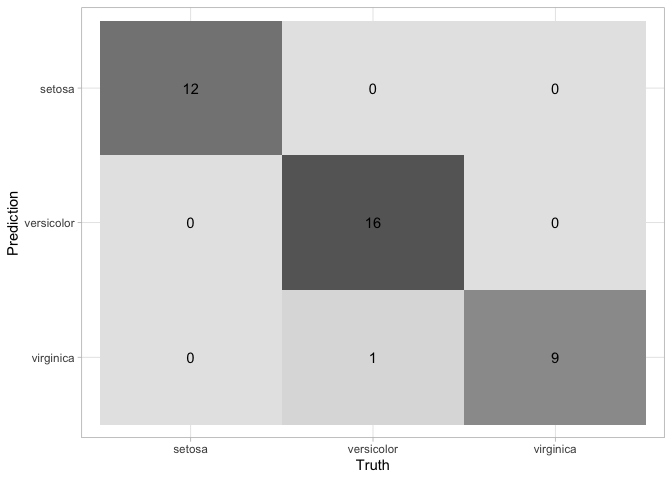

```r
collect_predictions(final_glmnet) %>%
  conf_mat(species, .pred_class) %>%
  autoplot(type = 'heatmap')
```

```r
collect_metrics(final_rf)
```

```
## # A tibble: 2 × 4
##   .metric  .estimator .estimate .config
##   <chr>    <chr>          <dbl> <chr>
## 1 accuracy multiclass     0.974 Preprocessor1_Model1
## 2 roc_auc  hand_till      0.998 Preprocessor1_Model1
```

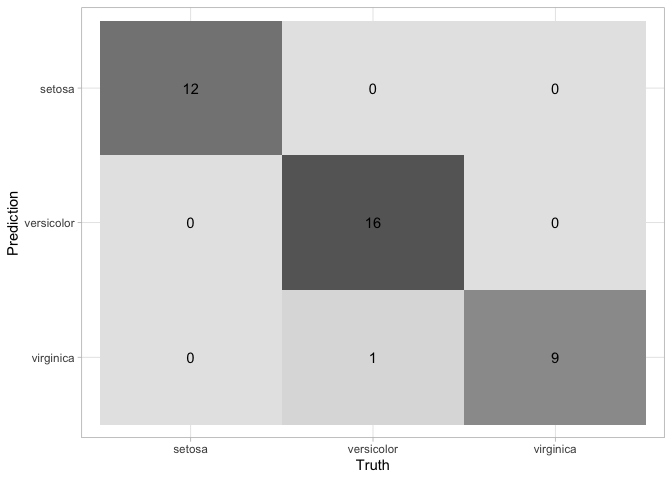

```r
collect_predictions(final_rf) %>%
  conf_mat(species, .pred_class) %>%
  autoplot(type = 'heatmap')
```

## Final thoughts

Special thanks to **Julia Silge**, **David Robinson** and **Andrew Couch** for creating and sharing many amazing learning resources for mastering the tidyverse and tidymodels data science packages.